# ЕГЭ 2018 Вариант 19 EGE 2018 Variant 19

Использованы материалы:

The list of used links and books:

[ЕГЭ 2018. Математика. Профильный уровень. 20 вариантов тестов. Тематическая рабочая тетрадь.](https://drive.google.com/file/d/0B8CJrELbJAyodmtvbV8xcEtZXzA/view)

[ЕГЭ 2017. Математика. Решение задачи 16 (профильный уровень)](https://books.google.ru/books?id=UfYiDQAAQBAJ&printsec=frontcover#v=onepage&q&f=false)

[SymPy Tutorials](http://nbviewer.jupyter.org/url/www.inp.nsk.su/~grozin/python/sympy.ipynb)

[LaTeX Mathematics](https://en.wikibooks.org/wiki/LaTeX/Mathematics)

[Метод рационализации неравенств (логарифмы)](http://internat.msu.ru/wp-content/uploads/2015/11/Metod-ratsionalizatsii-neravenstv-1.pdf)

```python
%%html
<style>
@import url('https://fonts.googleapis.com/css?family=Roboto&effect=3d|scuffed-steel|static|canvas-print|');
a, h1 h2, h3, h4, div.text_cell_render {font-family: 'Roboto'; text-shadow: 4px 4px 4px #aaa;}

h2, h3, div.output_prompt, div.output_area pre {color: slategray;}
h1, h4, div.input_prompt {color: steelblue;}
a, div.output_subarea {color: darkblue;}

span {text-shadow: 4px 4px 4px #aaa;}

body, div.output_stderr pre{background-color: aliceblue;}
div.output_stderr {background-color: slategray;}
</style>
```

```python
import numpy
import pandas
import math

import matplotlib.pyplot as plt
import matplotlib.patches as pat
from mpl_toolkits.mplot3d import Axes3D
from mpl_toolkits.mplot3d.art3d import Poly3DCollection, Line3DCollection

from __future__ import unicode_literals

import matplotlib
%matplotlib inline
```

```python
import sympy
from sympy import *
from sympy import init_printing
init_printing()
```

```python
answer_dictionary = dict()
```

## Часть 1 Part 1

[figure not shown]

### Задание 1 / Task 1

При оплате услуг через платежный терминал взымается комиссия 1%.

Терминал принимает суммы, кратные 10 рублям.

Месячная плата за Интернет составляет 950 рублей.

Какую минимальную сумму нужно положить в приемное устройство терминала, чтобы на счету фирмы, предоставляющей интернет-услуги, оказалась сумма, не меньшая 950 рублей?

During paying for services through a payment terminal, a commission of 1% is charged.

The terminal accepts amounts that are multiples of 10 rubles.

The monthly fee for the Internet is 950 rubles.

What is the minimum money amount to put in the terminal receiving device, so that the company that provides Internet services could get not less than 950 rubles?

Сумма оплаты Интернета с комиссией равна:

The Internet payment with a commission is:

$950 * (1 + 0.01) = 959.5$

Минимальная сумма, больше 959,5 и кратная 10, равна 960.

The minimum amount, more than 959.5 and a multiple of 10, is 960.

```python
answer_dictionary[1] = str(960)
```

[figure not shown]

### Задание 2 / Task 2

В аэропорту чемоданы пассажиров поднимают в зал выдачи багажа по транспортной ленте.

При проектировании транспортера необходимо учитывать допустимую силу натяжения ленты транспортера.

На рисунке изображена зависимость натяжения ленты от угла наклона транспортера к горизонту при рассчетной нагрузке.

На оси абсцисс откладывается угол подъема в градусах, на оси ординат - сила натяжения транспортной ленты (в килограммах силы).

При каком угле наклона сила натяжения достигает 150 кгс? ответ дайте в градусах.

At the airport, the suitcases of passengers are lifted into the baggage claim hall on the transport tape.

When designing the conveyor, it is necessary to take into account the permissible tension of the transport tape.

The figure shows the tension of the tape depended from the angle of inclination of the conveyor to the horizon at the calculated load.

On the abscissa axis, the elevation angle in degrees is plotted, on the ordinate axis - the tension force of the transport tape (in kilograms of force).

At what angle of inclination tension force reaches 150 kgf? Give the answer in degrees.

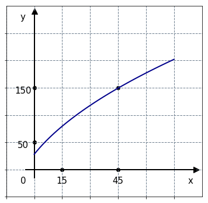

```python
plt.figure(figsize=(6,6))
plt.grid(c='slategray', ls='--', lw=1)

plt.axhline(0, 0.1, 0.97, c='black', lw=2)
plt.axvline(0, 0.1, 0.97, c='black', lw=2)

XY = [[[5.5,-0.5,-0.5,-0.6,0.8,-0.7,2.8],
       [-0.5,5.5,-0.5,0.8,-0.5,2.8,-0.5]]]
L = ['x','y','0','50','15','150','45']

for i in range(7):
    plt.text(XY[0][0][i],XY[0][1][i],
             L[i],fontsize=15)

plt.scatter(0,5.8, marker='^', s=100, c='black')
plt.scatter(5.8,0, marker='>', s=100, c='black')
plt.scatter([1,0,3,3,0],[0,1,3,0,3], c='black')

x = numpy.linspace(0,5)
y = [2.3 * (el + 0.8) ** 0.5 - 1.5 for el in x]
plt.plot(x, y, c='darkblue', lw=2)

plt.xlim(-1,6)
plt.ylim(-1,6)
plt.xticks(numpy.arange(-1, 6, step=1),visible=False)
plt.yticks(numpy.arange(-1, 6, step=1),visible=False);
```

### Ответ / Answer: 45

```python
answer_dictionary[2]=str(45)
```

[figure not shown]

### Задание 3 / Task 3

На клетчатой бумаге с размером клетки 1 х 1 изображен треугольник ABC.

Найдите длину его средней линии, параллельной стороне AB.

On a graph paper with a cell size of 1 x 1, the triangle ABC is depicted.

Find the length of its midline parallel to the side AB.

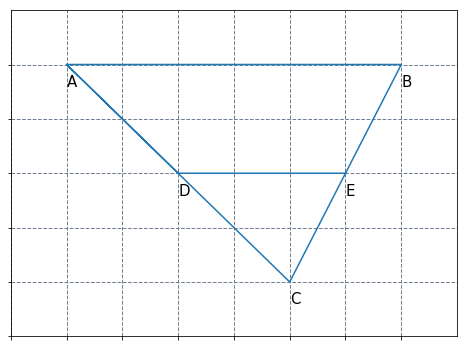

```python
plt.figure(figsize=(8,6))
plt.grid(c='slategray',ls='--',lw=1)

XY = [[[1,7,5,1,3,6], [5,5,1,5,3,3]]]
L = ['A','B','C','','D','E']

for x,y in XY:
    plt.plot(x,y)
for i in range(6):
    plt.text(XY[0][0][i],XY[0][1][i]-0.4,
             L[i],fontsize=15)


plt.xlim(0,8)
plt.ylim(0,6)
plt.xticks(numpy.arange(0, 8, step=1),visible=False)
plt.yticks(numpy.arange(0, 6, step=1),visible=False);
```

Средняя линия DE параллельна стороне AB треугольника ABC и равна ее половине.

The middle line DE is parallel to the side AB of the triangle ABC and is equal to its half.

$6 / 2 = 3$

### Ответ / Answer: 3

```python
answer_dictionary[3]=str(3)
```

[figure not shown]

### Задание 4 / Task 4

На чемпионате по спортивной гимнастике выступают 20 спортсменов, среди них 2 гимнастки из России и 10 гимнасток из США.

Порядок выступлений определяется жеребьёвкой.

Найдите вероятность того, что восьмой будет выступать гимнастка из России.

At the championship in gymnastics perform 20 athletes, among them 2 gymnasts from Russia and 10 gymnasts from the United States.

The order of performances is determined randomly.

Find the probability that the eighth will be a gymnast from Russia.

Вероятность выступать первой, второй, ..., восьмой, ..., двадцатой (на любом конкретном месте)

при случайном выборе порядка выступлений у каждой из российских спортсменок равна 1/20 = 0.05.

Гимнасток из России двое, значит вероятность того, что восьмой будет выступать россиянка равна 2/20 = 0.1.

The probability of performing the first, second, ..., eighth, ..., twentieth (any particular place)

at a casual choice of the order of performances for each of the Russian sportswomen is equal 1/20 = 0.05.

There are two gymnasts from Russia among 20 athletes, then the probability that the eighth will be Russian is 2/20 = 0.1.

### Ответ / Answer: 0.1

```python
answer_dictionary[4]=str(2/20)
```

[figure not shown]

### Задание 5 / Task 5

Найдите корень уравнения $x^2 + 3 * x - 10 = 0$.

Если уравнение имеет более одного корня, укажите больший из них.

Find the root of the equation $x^2 + 3 * x - 10 = 0$.

If the equation has more than one root, specify the larger one.

$x^2 + 3 * x - 10 = 0$

$D = 3^2 - 4 * (-10) = 49$

$x = \large{\frac{-3 \pm \sqrt{49}}{2 * 1}}$

$x_1 = 2, x_2 = -5$

### Ответ / Answer: 2

```python
answer_dictionary[5]=str(2)
```

[figure not shown]

### Задание 6 / Task 6

Отрезки AB и BC являются хордами окружности с центром O.

Найдите угол ACB, если угол ABO равен $23^o$. Ответ дайте в градусах.

The segments AB and BC are chords of a circle with center O.

Find the angle ACB if the angle ABO is $23^o$. Give the answer in degrees.

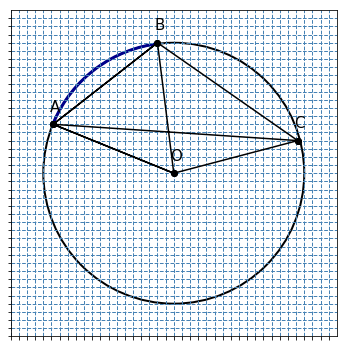

```python
f = plt.figure(figsize=(6,6))
ax = f.add_subplot(1, 1, 1, aspect=1)
ax.grid(c='steelblue', ls='--', lw=1)

circle = pat.Circle((0, 0), 8, lw=2,
                    edgecolor='black',
                    facecolor='none')
arc = pat.Arc((0, 0), 16, 16, lw=3,
              theta1=96, theta2=157,
              edgecolor='darkblue',
              facecolor='none')
ax.add_artist(circle)
ax.add_artist(arc)

XY = [[[-7.4,-1,7.6,0,-7.4,-1,0,-7.4,7.6],
       [3,8,2,0,3,8,0,3,2]]]
L = ['A','B','C','O']

for x,y in XY:
    plt.plot(x,y,'-o',c='black')
for i in range(4):
    plt.text(XY[0][0][i]-0.2,XY[0][1][i]+0.8,
             L[i],fontsize=15)

plt.xlim(-10,10)
plt.ylim(-10,10)
plt.xticks(numpy.arange(-10,10,step=0.5),visible=False)
plt.yticks(numpy.arange(-10,10,step=0.5),visible=False);
```

Величина вписанного угла в два раза меньше центрального, опирающегося на ту же дугу.

The value of the inscribed angle is half the value of the central angle, supported by the same arc.

$AO = OB \implies \triangle AOB: \angle OAB = \angle OBA = 23^o \implies $

$\angle AOB = 180^o - 2 * \angle OAB = 180^o - 2 * 23^o = 134^o$

$\frown {AB}: \angle AOB = 134^o, \angle ACB = 134^o / 2 = 67^o$

### Ответ / Answer: 67

```python
answer_dictionary[6]=str(int((180-2*23)/2))
```

[figure not shown]

### Задание 7 / Task 7

На рисунке изображены график функции $y = f'(x)$ - производной функции $f(x)$, и восемь точек на оси абсцисс:

The figure shows the graph of the function $y' = f(x)$ - the derivative of the function $f (x)$, and eight points on the abscissa:

$x_1,x_2,x_3,x_4,x_5,x_6,x_7,x_8$.

Сколько из этих точек принадлежат промежуткам возрастания функции $f(x)$?

How many of these points belong to the increasing intervals of the function $f(x)$?

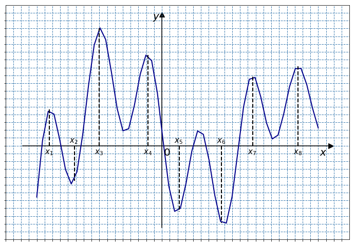

```python
f = plt.figure(figsize=(12,9))
ax = f.add_subplot(1, 1, 1, aspect=1)
ax.grid(c='steelblue', ls='--', lw=1)
ax.axhline(0, 0.05, 0.95, c='black')
ax.axvline(0, 0.05, 0.95, c='black')

def f(x,a=7,b=0.7,c=1.25,d=-3.2,e=+1):
    exp = (math.pow(x, 2) + math.pow(x, 5)) * (-0.1)**5
    return a * math.exp(exp) * math.cos(b*x+d) * math.sin(c*x)+e

x = numpy.linspace(-8,10)
y = [f(el) for el in x]
ax.plot(x, y, c='darkblue', lw=2)

vl = [-7.2,-5.6,-4,-0.9,1.1,3.8,5.8,8.7]
for v in vl:
    ax.plot([v,v], [0,f(v)], lw=2, ls='--', c='black')

v = numpy.array([vl, [-0.5,0.2,-0.5,-0.5,0.2,0.2,-0.5,-0.5,-0.5],
                 [r'$x_1$',r'$x_2$',r'$x_3$',r'$x_4$',r'$x_5$',
                  r'$x_6$',r'$x_7$',r'$x_8$']])
for i in range(8):
    plt.text(float(v[0][i]-0.3),float(v[1][i]),v[2][i],fontsize=15)

plt.text(10.1,-0.6,r'$x$', fontsize=20)
plt.text(-0.6,8.1,r'$y$', fontsize=20)
ax.scatter(0,8.4, marker='^', s=100, c='black')
ax.scatter(10.8,0, marker='>', s=100, c='black')
plt.text(0.1,-0.6,r'$0$', fontsize=20)

plt.xlim(-10,12)
plt.ylim(-6,9)
plt.xticks(numpy.arange(-10,12, step=0.5), visible=False)
plt.yticks(numpy.arange(-6,9, step=0.5), visible=False);
```

Функция возрастает, если ее производная положительна. В данном случае производная положительна в пяти точках.

The function grows if its derivative is positive. In this case, the derivative is positive at five points.

$x_1,x_3,x_4,x_7,x_8$.

### Ответ / Answer: 5

```python
answer_dictionary[7] = str(5)
```

[figure not shown]

### Задание 8 / Task 8

Найдите объем многогранника, вершинами которого являются точки $A,B,A_1,B_1,C_1$

правильной треугольной призмы $ABCA_1B_1C_1$,

площадь основания которой равна 3, а боковое ребро равно 7.

Find the volume of the polyhedron with vertices at the points $A, B, A_1, B_1, C_1$

of the regular triangular prism $ABCA_1B_1C_1$

with the base area equal to 3, and the lateral edge equal to 7.

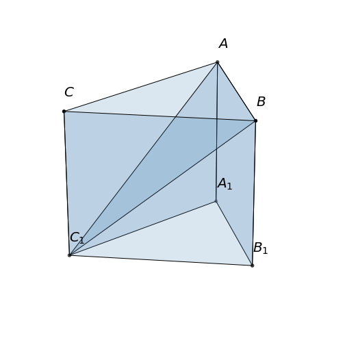

```python
f = plt.figure(figsize=(9,9))
ax = f.add_subplot(111, projection='3d')

v = numpy.array([[5,10,0], [10,5,0], [5,10,5], [10,5,5],
                 [1,1,0], [1,1,5]])
ax.scatter3D(v[:, 0], v[:, 1], v[:, 2], color='black')

verts = [ [v[0],v[2],v[3],v[1]],
          [v[0],v[4],v[5],v[2]],
          [v[1],v[4],v[5],v[3]],
          [v[4],v[2],v[3]] ]
letter_symbols = numpy.array([r'$A_1$',r'$B_1$',r'$A$',
                              r'$B$',r'$C_1$',r'$C$'])

for i in range(len(letter_symbols)):
    ax.text(v[i][0], v[i][1], v[i][2]+0.5,
            letter_symbols[i], color='black', fontsize=20)

lines = Poly3DCollection(verts, lw=1, alpha=0.2,
                         edgecolors='black', facecolor='none')
lines.set_facecolor('steelblue')

ax.add_collection3d(lines)
plt.axis('off');
```

$V_{ABCA_1B_1C_1} = S_{\triangle ABC} * AA_1 = 3 * 7 = 21$

Плоскость $ABC_1$ разделяет $ABCA_1B_1C_1$ на два многогранника $ABA_1B_1C_1$ и $ABCC_1$.

$ABCC_1$ - пирамида.

The plane $ABC_1$ divides $ABCA_1B_1C_1$ into two polyhedra $ABA_1B_1C_1$ and $ABCC_1$.

$ABCC_1$ is a pyramid.

$V_{ABCC_1} = S_{\triangle ABC} * CC_1 / 3 = 3 * 7 / 3 = 7$

$V_{ABA_1B_1C_1} = V_{ABCA_1B_1C_1} - V_{ABCC_1} = 21 - 7 = 14$

### Ответ / Answer: 14

```python
answer_dictionary[8] = str(14)
```

[figure not shown]

### Задание 9 / Task 9

Найдите значение выражения

Find the value of the expression

$\sqrt{18} - \sqrt{72} * \sin^2 \large{{\frac{5 * \pi}{8}}}$

$\sqrt{18} - \sqrt{72} * \sin^2 \large{{\frac{5 * \pi}{8}}} =$ $\sqrt{18} * (1 - 2 * \sin^2 \large{{\frac{5 * \pi}{8}}}) =$ $\sqrt{18} * (\cos^2\large{{\frac{5 * \pi}{8}}}$$ - \sin^2 \large{{\frac{5 * \pi}{8}}}) =$ $\sqrt{18} * \cos \large{{\frac{2 * 5 * \pi}{8}}} = $

$= \sqrt{18} * \cos \large{{\frac{5 * \pi}{4}}} = $ $\sqrt{18} * \cos \big(\pi + \large{{\frac{\pi}{4}}}$$\big) = \sqrt{18} * \big(-\cos \large{{\frac{\pi}{4}}}$$\big) =$ $-\sqrt{18} * \large{{\frac{\sqrt{2}}{2}}}$$= -\sqrt{9} = -3$

### Ответ / Answer: -3

```python
answer_dictionary[9]=str(-3)
```

[figure not shown]

### Задание 10 / Task 10

Расстояние от наблюдателя, находящегося на небольшой высоте $h$ м над землей, выраженное в километрах,

до наблюдаемой им линии горизонта вычисляется по формуле

$l = \large{\sqrt{\frac{R * h}{500}}}$, где $R = 6400$ км - радиус Земли.

На какой наименьшей высоте следует располагаться наблюдателю, чтобы он видел горизонт на расстоянии не менее 64 километров?

Ответ выразите в метрах.

The distance from the observer, located at a small height $h$ m above the ground, expressed in kilometers,

up to the observed horizon line is calculated by the formula

$l = \large{\sqrt{\frac{R * h}{500}}}$, where $R = 6400$ km - the radius of the Earth.

At what the smallest height should the observer be located that he could see the horizon at a distance of at least 64 kilometers?

The answer should be expressed in meters.

Подставим имеющиеся данные в уравнение.

Let's substitute the available data in the equation.

$64 = \large{\sqrt{\frac{6400 * h}{500}}}$

$64 = 8 * \large{\sqrt{\frac{h}{5}}}$

$8 = \large{\sqrt{\frac{h}{5}}}$

$64 = \large{\frac{h}{5}}$

$h = 320$

### Ответ / Answer: 320

```python
answer_dictionary[10]=str(320)
```

[figure not shown]

### Задание 11 / Task 11

Теплоход проходит по течению реки до пункта назначения 567 км и после стоянки возвращается в пункт отправления.

Найдите скорость теплохода в неподвижной воде, если

- скорость течения равна 3 км/ч,
- стоянка длится 6 часов,
- а в пункт отправления телоход возвращается через 54 часа после отплытия из него.

Ответ дайте в км/ч.

The motor ship passes along the river to the destination of 567 km and after the berth is returned to the point of departure.

Find the speed of the ship in immobile water, if

- the velocity of river flow is 3 km / h,
- the berth lasts 6 hours,
- and at the point of departure, the ship is returned 54 hours after departure from it.

Give the answer in km / h.

Пусть x - скорость теплохода в неподвижной воде.

Let's denote x - the ship velocity in immobile water.

$\large{\frac{567}{x + 3} + \frac{567}{x - 3}}$$ + \ 6 = 54$

$567 * (x - 3) + 567 * (x + 3) = 48 * (x + 3) * (x - 3)$

$1134 * x = 48 * x^2 - 48 * 9$

$48 * x^2 - 1134 * x - 48 * 9 = 0$

$8 * x^2 - 189 * x - 72 = 0$

$D = 189^2 - 4 * 8 * (-72) = 38025$

$x = \large{\frac{189 + \sqrt{38025}}{2 * 8}}$

$x = 24$

### Ответ / Answer: 24

```python
answer_dictionary[11]=str(int((189 + 195) / 16))
```

[figure not shown]

### Задание 12 / Task 12

Найдите наименьшее значение функции

Find the least value of the function

$y = (21 - x) * e^{22 - x}$

на отрезке $[16;25]$.

on the interval $[16;25]$.

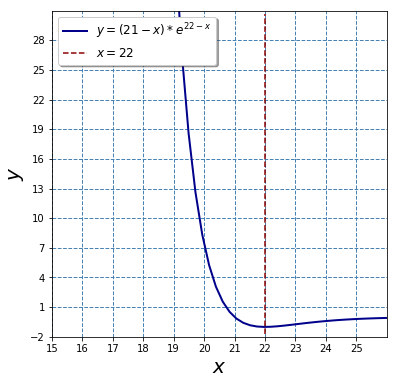

```python
f = plt.figure(figsize=(6,6))
ax = f.add_subplot(1, 1, 1)
ax.grid(c='steelblue', ls='--', lw=1)

def f(x):
    return (21 - x) * math.e ** (22 - x)

x = numpy.linspace(15,26)
y = [f(el) for el in x]
ax.plot(x, y, c='darkblue', lw=2,
        label=r'$y = (21 - x) * e^{22 - x}$')

ax.axvline(22, 0.01, 0.99, c='darkred',
           ls='--',label=r'$x=22$')

plt.xlim(15,26)
plt.ylim(-2,31)
plt.xticks(numpy.arange(15,26, step=1))
plt.yticks(numpy.arange(-2,31, step=3))

plt.xlabel(r'$x$', fontsize=20)
plt.ylabel(r'$y$', fontsize=20)
plt.legend(fontsize=12, shadow=True, loc=2);
```

Наименьших значений непрерывная функция может достигать в точках, где первая производная равна нулю, а вторая производная положительна.

The minimum value of a continuous function can be reached at points where the first derivative is equal to zero, and the second derivative is positive.

```python
x = Symbol('x')
y = (21 - x) * E ** (22 - x)
```

```python
# производная | the first derivative
diff(y,x)
```

$$- \left(- x + 21\right) e^{- x + 22} - e^{- x + 22}$$

```python
# производная равна нулю ∣ the first derivative is 0
solve(diff(y,x),x)
```

$$\left [ 22\right ]$$

```python
# вторая производная / the second derivative
diff(diff(y,x),x)
```

$$\left(- x + 21\right) e^{- x + 22} + 2 e^{- x + 22}$$

```python
# y''(22) > 0 => min
diff(diff(y,x),x).subs({x:22})
```

$$1$$

```python
# y(22)
y.subs({x:22})
```

$$-1$$

```python
answer_dictionary[12] = str(y.subs({x:22}))
```

## Часть 2 Part 2

[figure not shown]

### Задание 13 / Task 13

a) Найдите корень уравнения:

a) Find the root of the equation:

$4 * \cos^2 x - 12 * \cos \ x + 5 = 0$.

б) Найдите все корни этого уравнения, принадлежащие промежутку

b) Find all the roots of this equation that belong to the interval

$\bigg[-\pi; \large{\frac{5 * \pi}{2}} \bigg]$.

a)

$4 * \cos^2 x - 12 * \cos \ x + 5 = 0$

$D = 144 - 4 * 4 * 5 = 64$

$cos \ x = \large{\frac{12 \pm \sqrt{64}}{2 * 4}}$

$cos \ x = 2.5$$ \; \lor \; cos \ x = \large{\frac{1}{2}}$

$x \in \emptyset \; \lor \; x = \pm \frac{\pi}{3} \pm 2 * \pi * n; \; n \in \mathbb{N}$

б)

$\large{-\frac{\pi}{3}; \frac{\pi}{3}; \frac{5 * \pi}{3}; \frac{7 * \pi}{3}}$

### Ответ / Answer:

#### a) $\pm \frac{\pi}{3} \pm 2 * \pi * n; \; n \in \mathbb{N}$;

#### б) $\large{-\frac{\pi}{3}; \frac{\pi}{3}; \frac{5 * \pi}{3}; \frac{7 * \pi}{3}}$

```python
# check the decision method
x = Symbol('x')
g = 4 * (cos(x)) ** 2  - 12 * cos(x) + 5
```

```python
g
```

$$4 \cos^{2}{\left (x \right )} - 12 \cos{\left (x \right )} + 5$$

```python
# :)
solve(g,x)
```

$$\left [ \frac{\pi}{3}, \quad \frac{5 \pi}{3}, \quad 2 \pi - \operatorname{acos}{\left (\frac{5}{2} \right )}, \quad \operatorname{acos}{\left (\frac{5}{2} \right )}\right ]$$

```python
N(-pi), N(-solve(g,x)[0]), N(solve(g,x)[0]), N(solve(g,x)[1]), N(solve(g,x)[0]+2*pi),N(5*pi/2)
```

$$\left ( -3.14159265358979, \quad -1.0471975511966, \quad 1.0471975511966, \quad 5.23598775598299, \quad 7.33038285837618, \quad 7.85398163397448\right )$$

```python
answer_dictionary[13] = 'a)±π/3±2πn; n∈ℕ; б)−π/3;π/3;5π/3;7π/3'
```

[figure not shown]

### Задание 14 / Task 14

В правильной шестиугольной пирамиде SABCDEF боковые ребра равны 2, а стороны основания - 1.

а) Докажите, что плоскость, проходящая через вершину S и середины ребер AF и CD, перпендикулярна плоскости основания.

б) Найдите косинус угла между прямой AC и плоскостью SAF.

In the regular hexagonal pyramid SABCDEF, the lateral edges are equal to 2, and the sides of the base are 1.

a) Prove that the plane passing through the vertex S and the midpoints of the edges AF and CD is perpendicular to the plane of the base.

b) Find the cosine of the angle between the straight line AC and the plane SAF.

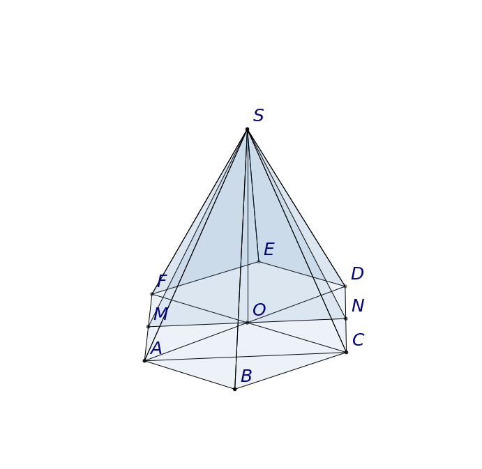

```python
f = plt.figure(figsize=(12,12))
ax = f.add_subplot(111, projection='3d')

v = numpy.array([[5,0,0],[10,0,0],[13,5,0],
                 [10,10,0],[5,10,0],[2,5,0],[7.5,5,5],
                 [3.5,2.5,0],[11.5,7.5,0],[7.5,5,0]])
letters = [r'$A$',r'$B$',r'$C$',r'$D$',r'$E$',r'$F$',
           r'$S$',r'$M$',r'$N$',r'$O$' ]

ax.scatter3D(v[:, 0],v[:, 1],v[:, 2],color='black')

verts = [ [v[0],v[1],v[6]], [v[1],v[2],v[6]], [v[2],v[3],v[6]],
          [v[3],v[4],v[6]], [v[4],v[5],v[6]], [v[5],v[0],v[6]],
          [v[6],v[7],v[8]], [v[0],v[2]], [v[6],v[9]], [v[0],v[3]], [v[2],v[5]],]

piramid = Poly3DCollection(verts,lw=1,alpha=0.1,
                           edgecolors='black',facecolor='none')
piramid.set_facecolor('steelblue')
ax.add_collection3d(piramid)

for i in range(10):
    ax.text(v[i][0]+0.2,v[i][1]+0.1,v[i][2]+0.2,
            letters[i],fontsize=25,color='darkblue')

plt.axis('off');
```

Пусть $O$ - центр основания правильной шестиугольной пирамиды $SABCDEF$.

Let $O$ be the base center of the regular hexagonal pyramid $SABCDEF$.

1)

$ABCDEF$ - правильный шестиугольник.

$ABCDEF$ is a regular hexagon.

$AF = CD, AF\|CD, AC \bot AF, AC \bot CD$

$AM = MF, CN = CD \implies AC \| MN \implies MN \bot AF, MN \bot CD$

$\triangle AOF: AO = OF, AM = MF \implies MO \bot AF \implies O \in MN \implies SO \subset (SMN)$

$SO \bot (ABC) \implies (SMN) \bot (ABC)$

2)

$\triangle SAF: SA = SF, AM = MF \implies SM \bot AF$

$SO \bot MO, MO \bot AF$

$\angle(AC,SAF) = \angle (MO,SAF) = \angle SMO$

$SM = \sqrt{SA^2 - AM^2} = \sqrt{SA^2 - AF^2/4} = \sqrt{2^2 - 1^2/4} = \frac{\sqrt{15}}{2}$

MO - радиус вписанной в правильный шестиугольник окружности.

MO is the radius of a circle inscribed in the regular hexagon.

$MO = AF * \sqrt{3}/2 = \frac{\sqrt{3}}{2}$

$\cos \angle SMO = MO / SM = \frac{\sqrt{3}}{2} / \frac{\sqrt{15}}{2} = \frac{\sqrt{3} * 2}{2 * \sqrt{15}} = \frac{\sqrt{5}}{5}$

### Ответ / Answer: $\frac{\sqrt{5}}{5}$

```python
answer_dictionary[14] = '√5/5'
```

[figure not shown]

### Задание 15 / Task 15

Решите неравенство:

Solve the inequality:

$\large{\log_3{\frac{1}{x}} + \log_3{(x^2 + 3 * x - 9)} \leq \log_3{\bigg(x^2 + 3 * x + \frac{1}{x} - 10\bigg)}}$

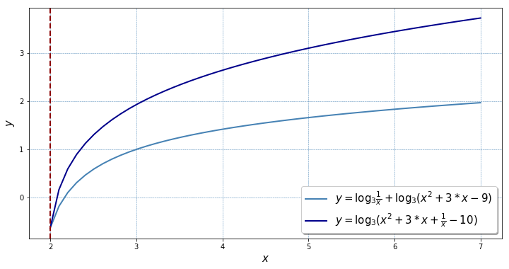

```python
x = numpy.linspace(2,7)
def f1(el): return math.log((1 / el),3) + math.log((el ** 2 + 3 * el - 9),3)
def f2(el): return math.log((el ** 2 + 3 * el + 1 / el - 10),3)

y1 = [f1(el) for el in x]
y2 = [f2(el) for el in x]

plt.figure(figsize=(12,6))
plt.plot(x, y1, c='steelblue', lw=2, label=r'$y = \log_3{\frac{1}{x}} + \log_3{(x^2 + 3 * x - 9)}$')
plt.plot(x, y2, c='darkblue', lw=2, label=r'$y = \log_3{(x^2 + 3 * x + \frac{1}{x} - 10)}$')

plt.grid(c='steelblue',ls='--',lw=0.5)
plt.axvline(2, c='darkred',ls='--',lw=2)

plt.xlabel(r'$x$', fontsize=15)
plt.ylabel(r'$y$', fontsize=15)
plt.legend(fontsize=15, shadow=True);
```

1) Область допустимых значений / Range of admissible values

$\begin{cases} x > 0 \\ x^2 + 3 * x - 9 > 0 \\ x^2 + 3 * x + \frac{1}{x} - 10 > 0 \end{cases} \; (*)$

2) Преобразования неравенства / Inequality transformations

$\large{\log_3{\frac{1}{x}} + \log_3{(x^2 + 3 * x - 9)} \leq \log_3{\bigg(x^2 + 3 * x + \frac{1}{x} - 10\bigg)}}$

$\large{\log_3{(x + 3 - \frac{9}{x})} \leq \log_3{\bigg(x^2 + 3 * x + \frac{1}{x} - 10\bigg)}}$

$\large{x + 3 - \frac{9}{x} \leq x^2 + 3 * x + \frac{1}{x} - 10}$

$\large{x^2 + 2 * x + \frac{10}{x} - 13 \geq 0}$

$x^3 + 2 * x^2 - 13 * x + 10 \geq 0$

$x^3 - x^2 + 3 * x^2 - 3 * x - 10 * x + 10 \geq 0$

$(x - 1) * (x^2 + 3 * x - 10) \geq 0$

$(x - 1) * (x - 2) * (x + 5) \geq 0$

$-5 \leq x \leq 1 \lor x \geq 2$

3) 1), 2) $\implies$

a)

$-5 \leq x \leq 1 \cap (*) = \emptyset$

$-5 \leq x \leq 1 \land x > 0 \iff 0 < x \leq 1$

$0 < x \leq 1 \implies -9 < x^2 + 3 * x - 9 \leq -5$

$0 < x \leq 1 \implies (x^2 + 3 * x - 9)' = 2 * x + 3 > 0$

b)

$x \geq 2 \implies x^2 + 3 * x - 9 \geq 1 \implies x^2 + 3 * x - 9 > 0$

$x \geq 2 \implies (x^2 + 3 * x - 9)' = 2 * x + 3 > 0$

$x \geq 2 \implies x^2 + 3 * x + \frac{1}{x} - 10 \geq 0.5 \implies x^2 + 3 * x + \frac{1}{x} - 10 > 0$

$x \geq 2 \implies (x^2 + 3 * x + \frac{1}{x} - 10)' = 2 * x + 3 - 1/x^2 > 0$

### Ответ / Answer: $[2;+\infty)$

```python
answer_dictionary[15] = '[2;+∞)'
```

[figure not shown]

### Задание 16 / Task 16

Точка $B$ - середина отрезка $AC$, причем $AC = 6$.

Проведены три окружности радиуса 5 с центрами $A$, $B$ и $C$.

а) Докажите, что существует ровно шесть окружностей, касающихся всех трех данных.

б) Найдите радиусы всех таких окружностей.

The point $B$ is the midpoint of the segment $AC$, with $AC = 6$.

Three circles of radius 5 with centers $A$, $B$ and $C$ are drawn.

a) Prove that there are exactly six circles tangent to all three of these circles.

b) Find the radii of all such six circles.

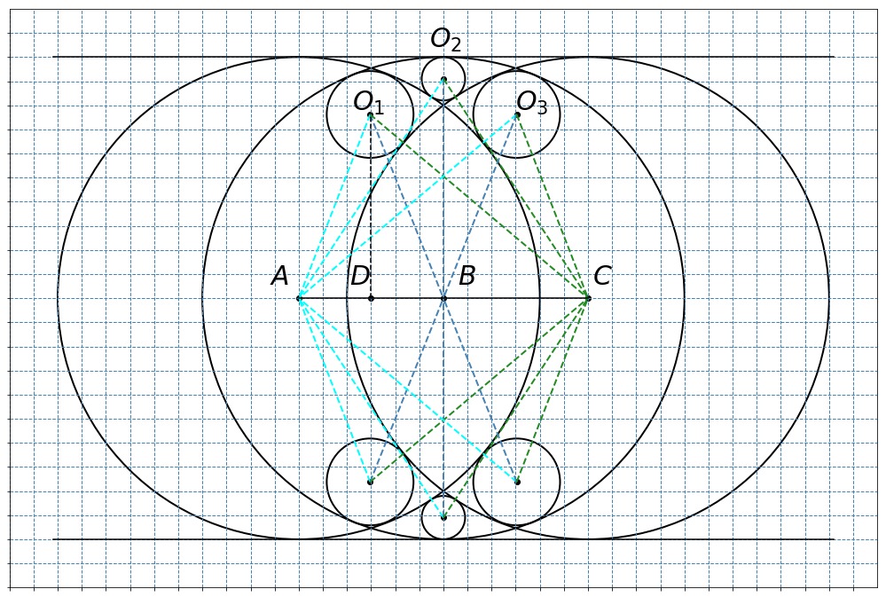

```python
f = plt.figure(figsize=(18,12))
ax = f.add_subplot(1, 1, 1, aspect=1)
ax.grid(c='steelblue', ls='--', lw=1)

XYR = [[-3,0,3,0,0,-1.52,1.52,-1.52,1.52,-1.5],
       [0,0,0,-4.55,4.55,3.81,3.81,-3.81,-3.81,0],
       [5,5,5,0.45,0.45,0.9,0.9,0.9,0.9]]


for i in range(9):
    circle = pat.Circle((XYR[0][i],XYR[1][i]),XYR[2][i],
                        lw=2,edgecolor='black',facecolor='none')
    ax.add_artist(circle)

for i in range(3,9):
    colors=['cyan','steelblue','forestgreen']
    for j in range(3):
        ax.plot([XYR[0][i],XYR[0][j]],[XYR[1][i],XYR[1][j]],
                ls='--',lw=2,c=colors[j])

l = [[-3.6,0.3,3.1,-1.9,-0.3,1.5,-1.95],[0.3,0.3,0.3,3.9,5.2,3.9,0.3],
     [r'$A$',r'$B$',r'$C$',r'$O_1$',r'$O_2$',r'$O_3$',r'$D$']]
for i in range(7):
    ax.text(l[0][i],l[1][i],l[2][i],fontsize=30)

ax.scatter(XYR[0],XYR[1],c='black')
ax.plot(XYR[0][:3],XYR[1][:3],c='black')
ax.plot([-1.5,-1.5],[0,3.8],ls='--',c='black')
ax.axhline(5,0.05,0.95,c='black')
ax.axhline(-5,0.05,0.95,c='black')

plt.xlim(-9,9)
plt.ylim(-6,6)
plt.xticks(numpy.arange(-9,9,step=0.5),visible=False)
plt.yticks(numpy.arange(-6,6,step=0.5),visible=False);
```

а)

Центры трех окружностей $A,B,C$ располагаются на одной прямой и не касаются друг друга ни внешним, ни внутренним образом, значит

построить какую-либо окружность, касающуюся всех трех данных только внешним или только внутренним образом, невозможно.

Случай касания двух окружностей внешним образом и одной - внутренним возможен только при внутреннем касании с окружностью с центром в середине отрезка.

Остаются только 3 случая касания для окружностей с центрами $A,B,C$ соответственно:

- внутреннее, внутреннее, внешнее;
- внешнее, внутреннее, внешнее;
- внешнее, внутреннее, внутреннее.

В силу симметричности построений относительно отрезка $AC$ общее число касающихся окружностей будет равно 6.

The centers of the three circles $A, B, C$ are on the same straight line and do not touch each other either externally or internally, so

it is impossible to construct a circle that touches to all three circles only by the external or internal method.

The case of two circles touching the outer and the inner one is possible only with an inner touch with a circle with the center in the middle of the segment.

There are only 3 touch cases for circles with centers $A, B, C$, respectively:

- internally, internally, externally;
- externally, internally, externally;
- externally, internally, internally.

Since the constructions are symmetric to the segment $AC$, the total number of tangent circles is 6.

б)

Пусть $x$ - радиус одной из искомых окружностей, тогда расстояния от центра этой окружности до $A,B,C$ равны $x + 5$ (внешнее касание) или $5 - x$ (внутреннее касание).

Let $x$ be the radius of one of the required circles, then the distances from the center of this circle to $A, B, C$ are equal to $x + 5$ (external touch) or $5 - x$ (internal touch).

I. Окружность с центром $O_2$ / The circle with the center $O_2$.

$\triangle ABO_2: AO_2^2 = AB^2 + O_2B^2 \implies (x + 5)^2 = (5 - x)^2 +3^2 \iff 20 * x = 9 \iff x = 0.45$

II. Окружность с центром $O_1$ / The circle with the center $O_1$.

$\triangle ABO_1: AO_1 = BO_1, O_1D \bot AB \implies AD = DB = 1.5 \implies CD = CB + BD = 4.5$

$\triangle ADO_1, CDO_1: DO_1^2 = AO_1^2 - AD^2 = CO_1^2 - CD^2 \implies CO_1^2 - AO_1^2 = 4.5^2 - 1.5^2 = 3 * 6 = 18$

$CO_1 = 5 + x, AO_1 = 5 - x \implies (5 + x)^2 - (5 - x)^2 = 18 \iff 20 * x = 18 \iff x = 0.9$

III. Окружность с центром $O_3$ - аналогично $O_1$. / The circle with the center $O_3$ - by the analogy with $O_3$.

### Ответ / Answer: 0.45; 0.9

```python
answer_dictionary[16] = '0.45; 0.9'
```

[figure not shown]

### Задание 17 / Task 17

В двух областях есть по 250 рабочих, каждый из которых готов трудиться по 5 часов в сутки на добыче алюминия и никеля.

В первой области один рабочий за час добывает 0.1 кг алюминия или 0.1 кг никеля.

Во второй области для добычи $x$ кг алюминия в день требуется $x^2$ человеко-часов труда,

а для добычи $y$ кг никеля в день требуется $y^2$ человеко-часов труда.

Для нужд промышленности можно использовать или алюминий, или никель,

причем 1 кг алюминия можно заменить 1 кг никеля.

Какую наибольшую массу металлов можно добыть в двух областях суммарно для нужд промышленности?

In two regions there are 250 workers, each of which is ready to work 5 hours a day on the extraction of aluminum and nickel.

In the first region, one worker per hour produces 0.1 kg of aluminum or 0.1 kg of nickel.

In the second region, $x^2$ man-hours of labor are required to produce $x$ kg of aluminum per day,

and $y^2$ man-hours of labor are required to extract $y$ kg of nickel per day.

For the needs of industry, either aluminum or nickel can be used,

1 kg of aluminum can be replaced with 1 kg of nickel.

What is the largest mass of metals that can be extracted in two regions in total for the needs of industry?

1) В данном случае алюминий и никель равноценны в применении, поэтому необходимо максимизировать количество любого добытого металла.

1) In this case, aluminum and nickel are equivalent in application, so it is necessary to maximize the amount of any extracted metal.

2) В первой области наибольшее количество металла можно добыть, используя труд всех рабочих по 5 часов в день: $0.1 * 5 * 250 = 125$.

2) In the first region, the greatest amount of metal can be extracted, using the labor of all workers for 5 hours a day: $ 0.1 * 5 * 250 = $ 125.

3) Рассмотрим вторую область.

3) Let's look at the second region.

Обозначим $q$ - количество рабочих, добывающих алюминий, $250 - q$ - добывающих никель.

Le'ts denote $q$ - the number of workers producing aluminum, $250 - q$ - producing nickel.

Количество добытого алюминия равно $\sqrt{5 * q}$, никеля - $\sqrt{5 * (250 - q)}$.

The amount of extracted aluminum is $\sqrt{5 * q}$, nickel - $\sqrt{5 * (250 - q)}$.

Во второй области количество добытого металла равно

In the second region, the amount of extracted metal is

$f(q) = \sqrt{5 * q} + \sqrt{1250 - 5 * q}; q \in \mathbb{N}$.

$f'(q) = \large{\frac{5}{2 * \sqrt{5 * q}} - \frac{5}{2 * \sqrt{1250 - 5 * q}}}$

$f'(q) = 0 \iff \sqrt{1250 - 5 * q} = \sqrt{5 * q} \iff 1250 - 5 * q = 5 * q \iff q = 125$

$f(125) = \sqrt{5 * 125} + \sqrt{1250 - 5 * 125} = 25 + 25 = 50$

4) $125 + 50 = 175$

### Ответ / Answer: 175

```python
answer_dictionary[17] = '175'
```

[figure not shown]

### Задание 18 / Task 18

Найдите все значения параметра $a$, при каждом из которых наибольшее значение функции $f(x) = |x - a| - x^2$ не меньше 1.

Find all the values of the parameter $a$, for each of which the largest value of the function $f(x) = |x - a| - x^2$ is at least 1.

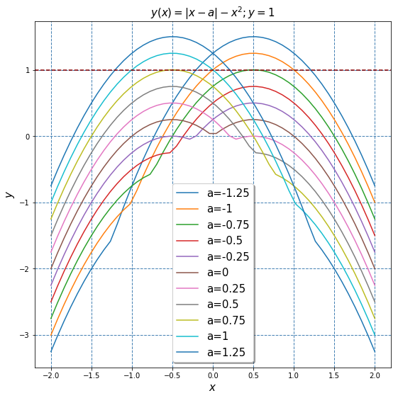

```python
def F(x,a): return abs(x - a) - x ** 2
X = numpy.linspace(-2,2)

plt.figure(figsize=(9,9))
for a in [-1.25, -1, -0.75, -0.5, -0.25, 0, 0.25, 0.5, 0.75, 1, 1.25]:
    plt.plot(X, [F(x,a) for x in X], label='a='+str(a))

plt.axhline(1, c='darkred', ls='--')
plt.legend(shadow=True, loc=8, fontsize=15)
plt.xlabel(r'$x$', fontsize=15)
plt.ylabel(r'$y$', fontsize=15)

plt.title(r'$y(x) = |x - a| - x^2; y = 1$', fontsize=15)
plt.grid(c='steelblue', ls='--', lw=1);
```

1)

$x - a \geq 0 \iff x \geq a$

$f(x) = x - a - x^2$

$f'(x) = - 2 * x + 1 = 0 \iff x = \frac{1}{2}$

$f''(x) = - 2 < 0 \implies f(\frac{1}{2}) = f_{max}$

$f_{max}(a) = \frac{1}{2} - a - (\frac{1}{2})^2 = \frac{1}{4} - a$

$f_{max}(a) \geq 1 \iff \frac{1}{4} - a \geq 1 \iff a \leq -\frac{3}{4}$

2)

$x - a < 0 \iff x < a$

$f(x) = - x + a - x^2$

$f'(x) = - 2 * x - 1 = 0 \iff x = -\frac{1}{2}$

$f''(x) = - 2 < 0 \implies f(-\frac{1}{2}) = f_{max}$

$f_{max}(a) = -(-\frac{1}{2}) + a - (-\frac{1}{2})^2 = \frac{1}{4} + a$

$f_{max}(a) \geq 1 \iff \frac{1}{4} + a \geq 1 \iff a \geq \frac{3}{4}$

### Ответ / Answer: $(-\infty; -0.75] \cup [0.75; +\infty)$

```python
answer_dictionary[18] = '(−∞;−0.75]∪[0.75;+∞)'
```

[figure not shown]

### Задание 19 / Task 19

Геометрическая прогрессия с отрицательной суммой состоит из четырёх членов.

Первый, третий и четвёртый её члены образуют возрастающую арифметическую прогрессию.

Найдите знаменатель данной геометрической прогрессии.

A geometric progression with a negative sum consists of four terms.

The first, third and fourth members form an increasing arithmetic progression.

Find the denominator of this geometric progression.

Пусть прогрессия состоит из $b_1, b_2, b_3, b_4$, $q$ - знаменатель прогрессии.

Let the progression consist of $b_1, b_2, b_3, b_4$, and $q$ is a denominator of the progression.

1)

Первый, третий и четвёртый её члены образуют возрастающую арифметическую прогрессию.

The first, third and fourth members form an increasing arithmetic progression.

$b_3 - b_1 = b_4 - b_3 > 0$

$q^2 * b_1 - b_1 = q^3 * b_1 - q^2 * b_1$

$q^3 * b_1 - 2 * q^2 * b_1 + b_1 = 0$

$b_1 * (q^3 - 2 * q^2 + 1) = 0$

$q^3 - 2 * q^2 + 1 = 0$

$q^2 * (q - 1) - (q^2 - 1) = 0$

$q^2 * (q - 1) - (q - 1) * (q + 1) = 0$

$(q - 1)* (q^2 - q - 1) = 0$

$q - 1 = 0 \lor q^2 - q - 1 = 0$

$D = 1 - 4 * (-1) = 5$

$q = 1 \lor q = \frac{1 - \sqrt{5}}{2} \lor q = \frac{1 + \sqrt{5}}{2}$

$q = 1 \implies b_1 = b_2 = b_3 = b_4$,

что противоречит условию о возрастающей арифметической прогрессии $b_1, b_3, b_4$.

which contradicts the condition of increasing arithmetic progression $ b_1, b_3, b_4 $.

2)

Сумма геометрическая прогрессии отрицательна.

The geometric progression sum is negative.

$b_1 + b_2 + b_3 + b_4 = b_1 * (q^4 - 1) / (q - 1) = b_1 * (q - 1) * (q + 1) * (q^2 + 1) / (q - 1) = b_1 * (q + 1) * (q^2 + 1)$

$b_1 * (q + 1) * (q^2 + 1) < 0 \iff b_1 * (q + 1) < 0 \iff (b_1 < 0 \land q > -1) \lor (b_1 > 0 \land q < -1)$

$\frac{1 - \sqrt{5}}{2} > -1; \; \frac{1 + \sqrt{5}}{2} > -1$

$b_1 < 0 \land q > -1 \; (*)$

$b_3 - b_1 > 0 \iff b_1 * (q^2 - 1) > 0 \; (**)$

$(*), \; (**) \implies q^2 - 1 < 0 \iff (q - 1) * (q + 1) < 0 \iff -1 < q < 1 \implies q = \frac{1 - \sqrt{5}}{2}$

Ответ / Answer: $\frac{1 - \sqrt{5}}{2}$

```python
answer_dictionary[19] = '(1−√5)/2'
```

## Ответы / Answers

| 1 | 2 | 3 | 4 | 5 | 6 | 7 | 8 | 9 | 10 | 11 | 12 |
| --- | --- | --- | --- | --- | --- | --- | --- | --- | --- | --- | --- |
| 960 | 45 | 3 | 0.1 | 2 | 67 | 5 | 14 | -3 | 320 | 24 | -1 |

| 13 | 14 | 15 | 16 | 17 | 18 | 19 |
| --- | --- | --- | --- | --- | --- | --- |
| a) $\pm \frac{\pi}{3} \pm 2 * \pi * n;$ $n \in \mathbb{N}$; б) $\large{-\frac{\pi}{3}; \frac{\pi}{3};} $ $\large{\frac{5 * \pi}{3}; \frac{7 * \pi}{3}}$ | $\frac{\sqrt{5}}{5}$ | $[2;+\infty)$ | 0.45; 0.9 | 175 | $(-\infty; -0.75] \cup [0.75; +\infty)$ | $\frac{1 - \sqrt{5}}{2}$ |

```python
answer_dictionary
```

```
{1: '960',
 2: '45',
 3: '3',
 4: '0.1',
 5: '2',
 6: '67',
 7: '5',
 8: '14',
 9: '-3',
 10: '320',
 11: '24',
 12: '-1',
 13: 'a)±π/3±2πn; n∈ℕ; б)−π/3;π/3;5π/3;7π/3',
 14: '√5/5',
 15: '[2;+∞)',
 16: '0.45; 0.9',
 17: '175',
 18: '(−∞;−0.75]∪[0.75;+∞)',
 19: '(1−√5)/2'}
```

[figure not shown]